# Appendix A: Association Model

Bradley Hopkins, Matthew Hoctor

2/13/2021

# 1 Import the dataset

Import the maternal smoking dataset from the preliminary analysis:

```r
CHDS <- read.csv("CHDS2.csv")
```

# 2 Crude Model

If we let $Y$ equal birthweight, and $X$ equal smoking category, the crude model can be conceptualized as:

$$Y = \beta_0 + \beta_1 X + \epsilon$$

Firstly, we will create $k-1 = 3$ dummy variables to represent the ordinal smoking category data; we can name them $SMK1$ for category 1, $SMK2$ for category 3, and $SMK3$ for category 3. The values of these variables will be assigned to 0 or 1 according to the reference cell coding approach:

If we let

$$\begin{split}
X_1=
\begin{cases}
1 \; \mbox{if in smoking category 1}\\
0 \; \mbox{otherwise}\\
\end{cases}\\
X_2=
\begin{cases}
1 \; \mbox{if in smoking category 2}\\
0 \; \mbox{otherwise}\\
\end{cases}\\
X_3=
\begin{cases}
1 \; \mbox{if in smoking category 3}\\
0 \; \mbox{otherwise}\\
\end{cases}
\end{split}$$

The following R code creates these dummy variables as defined above:

```r
CHDS$SMK1 <- ifelse(CHDS$SMK_cat == 1, 1,0)
CHDS$SMK2 <- ifelse(CHDS$SMK_cat == 2, 1,0)
CHDS$SMK3 <- ifelse(CHDS$SMK_cat == 3, 1,0)
```

The reformulated crude model can be expressed as:

$$Y = \beta_0 + \beta_1 X_1 + \beta_2 X_2+ \beta_3 X_3 + \epsilon$$

To test if a crude association can be established we can consider $H_0: \beta_1 = \beta_2 = \beta_3 = 0$, and test it at significance $\alpha = 0.05$ The following R code creates the crude model and reports summary and ANOVA data:

```r
lm.bwcrude <- lm(bwt ~ SMK1 + SMK2 + SMK3, data = CHDS)
summary(lm.bwcrude)
```

```
##
## Call:
## lm(formula = bwt ~ SMK1 + SMK2 + SMK3, data = CHDS)
##
## Residuals:
##     Min      1Q  Median      3Q     Max
## -4.4328 -0.7328 -0.0328  0.7214  3.6672
##
## Coefficients:
##             Estimate Std. Error t value Pr(>|t|)
## (Intercept)  7.73281    0.05442 142.091  < 2e-16 ***
## SMK1        -0.35223    0.11797  -2.986  0.00293 **
## SMK2        -0.76008    0.14163  -5.367 1.10e-07 ***
## SMK3        -0.46665    0.10790  -4.325 1.76e-05 ***
## ---
## Signif. codes:  0 '***' 0.001 '**' 0.01 '*' 0.05 '.' 0.1 ' ' 1
##
## Residual standard error: 1.062 on 676 degrees of freedom
## Multiple R-squared:  0.0585, Adjusted R-squared:  0.05432
## F-statistic:    14 on 3 and 676 DF,  p-value: 7.294e-09
```

```r
anova(lm.bwcrude)
```

```
## Analysis of Variance Table
##
## Response: bwt
##            Df Sum Sq Mean Sq F value    Pr(>F)
## SMK1        1   2.24  2.2415  1.9864    0.1592
## SMK2        1  24.04 24.0434 21.3074 4.682e-06 ***
## SMK3        1  21.11 21.1076 18.7056 1.755e-05 ***
## Residuals 676 762.80  1.1284
## ---
## Signif. codes:  0 '***' 0.001 '**' 0.01 '*' 0.05 '.' 0.1 ' ' 1
```

# 3 Full Model

To create the full model we will include all independent variables in the dataset except for maternal weight, as it is already a linear component of BMI, and will create colinearity without adding significantly to the model. The following R code creates the full model and reports summary and ANOVA data:

```r
lm.bwfull <- lm(bwt ~ SMK1 + SMK2 + SMK3 + gestwks + age + mheight + BMI, data = CHDS)
anova(lm.bwfull)
```

```
## Analysis of Variance Table
##
## Response: bwt
##            Df Sum Sq Mean Sq  F value    Pr(>F)
## SMK1        1   2.24   2.241   2.5258  0.112465
## SMK2        1  24.04  24.043  27.0938 2.578e-07 ***
## SMK3        1  21.11  21.108  23.7855 1.346e-06 ***
## gestwks     1 132.20 132.200 148.9717 < 2.2e-16 ***
## age         1   0.00   0.005   0.0055  0.941056
## mheight     1  25.18  25.184  28.3791 1.362e-07 ***
## BMI         1   9.07   9.073  10.2239  0.001451 **
## Residuals 672 596.34   0.887
## ---
## Signif. codes:  0 '***' 0.001 '**' 0.01 '*' 0.05 '.' 0.1 ' ' 1
```

```r
summary(lm.bwfull)
```

```
##
## Call:
## lm(formula = bwt ~ SMK1 + SMK2 + SMK3 + gestwks + age + mheight +
##     BMI, data = CHDS)
##
## Residuals:
##     Min      1Q  Median      3Q     Max
## -3.2737 -0.6128  0.0214  0.5605  3.2898
##
## Coefficients:
##              Estimate Std. Error t value Pr(>|t|)
## (Intercept) -7.658217   1.256767  -6.094 1.86e-09 ***
## SMK1        -0.176868   0.106465  -1.661  0.09712 .
## SMK2        -0.548731   0.126858  -4.326 1.75e-05 ***
## SMK3        -0.405474   0.096109  -4.219 2.79e-05 ***
## gestwks      0.231123   0.019405  11.910  < 2e-16 ***
## age         -0.003536   0.006670  -0.530  0.59621
## mheight      0.081685   0.014698   5.558 3.95e-08 ***
## BMI          0.045115   0.014110   3.197  0.00145 **
## ---
## Signif. codes:  0 '***' 0.001 '**' 0.01 '*' 0.05 '.' 0.1 ' ' 1
##
## Residual standard error: 0.942 on 672 degrees of freedom
## Multiple R-squared:  0.264,  Adjusted R-squared:  0.2563
## F-statistic: 34.43 on 7 and 672 DF,  p-value: < 2.2e-16
```

# 4 Parsimonious Model Selection by Backward-Elimination

To create a parsimonious model we will utilize the backward-elimination procedure starting from the full model above. In the first iteration of this procedure we will calculate the partial F-statistic for each independent variable (other than smoking category) in turn.

## 4.1 First Iteration

The summary function reports the coefficients and associated p-values (right column of table) from the full model:

```r
summary(lm.bwfull)
```

```
##
## Call:
## lm(formula = bwt ~ SMK1 + SMK2 + SMK3 + gestwks + age + mheight +
##     BMI, data = CHDS)
##
## Residuals:
##     Min      1Q  Median      3Q     Max
## -3.2737 -0.6128  0.0214  0.5605  3.2898
##
## Coefficients:
##              Estimate Std. Error t value Pr(>|t|)
## (Intercept) -7.658217   1.256767  -6.094 1.86e-09 ***
## SMK1        -0.176868   0.106465  -1.661  0.09712 .
## SMK2        -0.548731   0.126858  -4.326 1.75e-05 ***
## SMK3        -0.405474   0.096109  -4.219 2.79e-05 ***
## gestwks      0.231123   0.019405  11.910  < 2e-16 ***
## age         -0.003536   0.006670  -0.530  0.59621
## mheight      0.081685   0.014698   5.558 3.95e-08 ***
## BMI          0.045115   0.014110   3.197  0.00145 **
## ---
## Signif. codes:  0 '***' 0.001 '**' 0.01 '*' 0.05 '.' 0.1 ' ' 1
##
## Residual standard error: 0.942 on 672 degrees of freedom
## Multiple R-squared:  0.264,  Adjusted R-squared:  0.2563
## F-statistic: 34.43 on 7 and 672 DF,  p-value: < 2.2e-16
```

We can see that maternal age has the highest p-value (0.59621), and that the p-value is well above $\alpha = 0.10$; thus it will be removed. We can begin the second iteration with the full model excluding maternal age:

## 4.2 Second Iteration

```r
lm.bwfull_age <- lm(bwt ~ SMK1 + SMK2 + SMK3 + gestwks + mheight + BMI, data = CHDS)
summary(lm.bwfull_age)
```

```
##
## Call:
## lm(formula = bwt ~ SMK1 + SMK2 + SMK3 + gestwks + mheight + BMI,
##     data = CHDS)
##
## Residuals:
##     Min      1Q  Median      3Q     Max
## -3.2464 -0.6146  0.0266  0.5505  3.2585
##
## Coefficients:
##             Estimate Std. Error t value Pr(>|t|)
## (Intercept) -7.71966    1.25074  -6.172 1.16e-09 ***
## SMK1        -0.17633    0.10640  -1.657  0.09794 .
## SMK2        -0.54836    0.12679  -4.325 1.76e-05 ***
## SMK3        -0.40634    0.09604  -4.231 2.65e-05 ***
## gestwks      0.23114    0.01939  11.918  < 2e-16 ***
## mheight      0.08151    0.01469   5.550 4.12e-08 ***
## BMI          0.04422    0.01400   3.158  0.00166 **
## ---
## Signif. codes:  0 '***' 0.001 '**' 0.01 '*' 0.05 '.' 0.1 ' ' 1
##
## Residual standard error: 0.9415 on 673 degrees of freedom
## Multiple R-squared:  0.2636, Adjusted R-squared:  0.2571
## F-statistic: 40.16 on 6 and 673 DF,  p-value: < 2.2e-16
```

## 4.3 Variable Selection

If we denote gestational age as $X_4$, BMI as $X_5$, & maternal height as $X_6$ we can state the parsimonious as:

$$Y = \beta_0 + \beta_1 X_1 + \beta_2 X_2+ \beta_3 X_3 + \beta_4 X_4 + \beta_5 X_5 + \beta_6 X_6 + \epsilon$$

The following R code reports summary statistics and ANOVA table for this model:

```r
summary(lm.bwfull_age)
```

```
##
## Call:
## lm(formula = bwt ~ SMK1 + SMK2 + SMK3 + gestwks + mheight + BMI,
##     data = CHDS)
##
## Residuals:
##     Min      1Q  Median      3Q     Max
## -3.2464 -0.6146  0.0266  0.5505  3.2585
##
## Coefficients:
##             Estimate Std. Error t value Pr(>|t|)
## (Intercept) -7.71966    1.25074  -6.172 1.16e-09 ***
## SMK1        -0.17633    0.10640  -1.657  0.09794 .
## SMK2        -0.54836    0.12679  -4.325 1.76e-05 ***
## SMK3        -0.40634    0.09604  -4.231 2.65e-05 ***
## gestwks      0.23114    0.01939  11.918  < 2e-16 ***
## mheight      0.08151    0.01469   5.550 4.12e-08 ***
## BMI          0.04422    0.01400   3.158  0.00166 **
## ---
## Signif. codes:  0 '***' 0.001 '**' 0.01 '*' 0.05 '.' 0.1 ' ' 1
##
## Residual standard error: 0.9415 on 673 degrees of freedom
## Multiple R-squared:  0.2636, Adjusted R-squared:  0.2571
## F-statistic: 40.16 on 6 and 673 DF,  p-value: < 2.2e-16
```

```r
anova(lm.bwfull_age)
```

```
## Analysis of Variance Table
##
## Response: bwt
##            Df Sum Sq Mean Sq  F value    Pr(>F)
## SMK1        1   2.24   2.241   2.5285  0.112273
## SMK2        1  24.04  24.043  27.1228 2.541e-07 ***
## SMK3        1  21.11  21.108  23.8109 1.328e-06 ***
## gestwks     1 132.20 132.200 149.1310 < 2.2e-16 ***
## mheight     1  25.17  25.169  28.3928 1.352e-07 ***
## BMI         1   8.84   8.843   9.9755  0.001657 **
## Residuals 673 596.59   0.886
## ---
## Signif. codes:  0 '***' 0.001 '**' 0.01 '*' 0.05 '.' 0.1 ' ' 1
```

We can begin the analysis of effect modification and confounding:

# 5 Analysis of Effect Modification

## 5.1 BMI

For this step we wish to investigate if BMI is an effect-modifier which changes the association between smoking and birth weight. We can construct an association model with an interaction term for each of our dummy variables:

For light smoking:

$$Y = \beta_0 + \beta_1 X_1 + \beta_2 X_2+ \beta_3 X_3 + \beta_4 X_4 + \beta_5 X_5 + \beta_6 X_6 + \beta_7 X_1 X_5 + \epsilon$$

For moderate smoking:

$$Y = \beta_0 + \beta_1 X_1 + \beta_2 X_2+ \beta_3 X_3 + \beta_4 X_4 + \beta_5 X_5 + \beta_8 X_2 X_5 + \epsilon$$

For heavy smoking:

$$Y = \beta_0 + \beta_1 X_1 + \beta_2 X_2+ \beta_3 X_3 + \beta_4 X_4 + \beta_5 X_5 + + \beta_6 X_6 + \beta_9 X_3 X_5 + \epsilon$$

We wish to test the null hypothesis $H_0: \beta_7 = \beta_8 = \beta_9 = 0$. We can construct three linear models to test this hypothesis:

### 5.1.1 Light Smoking

```r
lm.par_X1BMI <- lm(bwt ~ SMK1 + SMK2 + SMK3 + gestwks + mheight + BMI + BMI*as.factor(SMK1), data = CHDS)
summary(lm.par_X1BMI)
```

```
##
## Call:
## lm(formula = bwt ~ SMK1 + SMK2 + SMK3 + gestwks + mheight + BMI +
##     BMI * as.factor(SMK1), data = CHDS)
##
## Residuals:
##     Min      1Q  Median      3Q     Max
## -3.2541 -0.6122  0.0196  0.5510  3.2557
##
## Coefficients: (1 not defined because of singularities)
##                      Estimate Std. Error t value Pr(>|t|)
## (Intercept)          -7.75065    1.25779  -6.162 1.24e-09 ***
## SMK1                  0.05895    0.95080   0.062  0.95058
## SMK2                 -0.54733    0.12694  -4.312 1.86e-05 ***
## SMK3                 -0.40560    0.09616  -4.218 2.80e-05 ***
## gestwks               0.23165    0.01951  11.871  < 2e-16 ***
## mheight               0.08127    0.01473   5.519 4.87e-08 ***
## BMI                   0.04541    0.01480   3.068  0.00224 **
## as.factor(SMK1)1           NA         NA      NA       NA
## BMI:as.factor(SMK1)1 -0.01135    0.04559  -0.249  0.80342
## ---
## Signif. codes:  0 '***' 0.001 '**' 0.01 '*' 0.05 '.' 0.1 ' ' 1
##
## Residual standard error: 0.9422 on 672 degrees of freedom
## Multiple R-squared:  0.2637, Adjusted R-squared:  0.256
## F-statistic: 34.38 on 7 and 672 DF,  p-value: < 2.2e-16
```

```r
anova(lm.par_X1BMI)
```

```
## Analysis of Variance Table
##
## Response: bwt
##                      Df Sum Sq Mean Sq  F value    Pr(>F)
## SMK1                  1   2.24   2.241   2.5250   0.11252
## SMK2                  1  24.04  24.043  27.0850 2.590e-07 ***
## SMK3                  1  21.11  21.108  23.7778 1.351e-06 ***
## gestwks               1 132.20 132.200 148.9232 < 2.2e-16 ***
## mheight               1  25.17  25.169  28.3533 1.380e-07 ***
## BMI                   1   8.84   8.843   9.9616   0.00167 **
## BMI:as.factor(SMK1)   1   0.06   0.055   0.0620   0.80342
## Residuals           672 596.54   0.888
## ---
## Signif. codes:  0 '***' 0.001 '**' 0.01 '*' 0.05 '.' 0.1 ' ' 1
```

The F-value and associated p-value are 0.0620 & 0.80342 respectively; thus we can conclude that BMI is not an effect-measure modifier of light smoking, at pre-defined significance $\alpha = 0.05$; the observed results are not inconsistent with $\beta_7 = 0$.

### 5.1.2 Moderate Smoking

```r
lm.par_X2BMI <- lm(bwt ~ SMK1 + SMK2 + SMK3 + gestwks + mheight + BMI + BMI*as.factor(SMK2), data = CHDS)
summary(lm.par_X2BMI)
```

```
##
## Call:
## lm(formula = bwt ~ SMK1 + SMK2 + SMK3 + gestwks + mheight + BMI +
##     BMI * as.factor(SMK2), data = CHDS)
##
## Residuals:
##     Min      1Q  Median      3Q     Max
## -3.2359 -0.6172  0.0233  0.5556  3.2592
##
## Coefficients: (1 not defined because of singularities)
##                      Estimate Std. Error t value Pr(>|t|)
## (Intercept)          -7.71381    1.25145  -6.164 1.22e-09 ***
## SMK1                 -0.17810    0.10651  -1.672  0.09497 .
## SMK2                 -1.30442    1.40683  -0.927  0.35415
## SMK3                 -0.40693    0.09610  -4.234 2.61e-05 ***
## gestwks               0.23183    0.01945  11.921  < 2e-16 ***
## mheight               0.08156    0.01469   5.550 4.11e-08 ***
## BMI                   0.04255    0.01435   2.966  0.00313 **
## as.factor(SMK2)1           NA         NA      NA       NA
## BMI:as.factor(SMK2)1  0.03587    0.06647   0.540  0.58964
## ---
## Signif. codes:  0 '***' 0.001 '**' 0.01 '*' 0.05 '.' 0.1 ' ' 1
##
## Residual standard error: 0.942 on 672 degrees of freedom
## Multiple R-squared:  0.264,  Adjusted R-squared:  0.2563
## F-statistic: 34.43 on 7 and 672 DF,  p-value: < 2.2e-16
```

```r
anova(lm.par_X2BMI)
```

```
## Analysis of Variance Table
##
## Response: bwt
##                      Df Sum Sq Mean Sq  F value    Pr(>F)
## SMK1                  1   2.24   2.241   2.5259  0.112462
## SMK2                  1  24.04  24.043  27.0942 2.578e-07 ***
## SMK3                  1  21.11  21.108  23.7859 1.345e-06 ***
## gestwks               1 132.20 132.200 148.9740 < 2.2e-16 ***
## mheight               1  25.17  25.169  28.3629 1.373e-07 ***
## BMI                   1   8.84   8.843   9.9650  0.001667 **
## BMI:as.factor(SMK2)   1   0.26   0.258   0.2912  0.589638
## Residuals           672 596.33   0.887
## ---
## Signif. codes:  0 '***' 0.001 '**' 0.01 '*' 0.05 '.' 0.1 ' ' 1
```

The F-value and associated p-value are 0.2912 & 0.589638 respectively; thus we can conclude that BMI is not an effect-measure modifier of moderate smoking, at pre-defined significance $\alpha = 0.05$; the observed results are not inconsistent with $\beta_8 = 0$.

### 5.1.3 Heavy Smoking

```r
lm.par_X3BMI <- lm(bwt ~ SMK1 + SMK2 + SMK3 + gestwks + mheight + BMI + BMI*as.factor(SMK3), data = CHDS)
summary(lm.par_X3BMI)
```

```
##
## Call:
## lm(formula = bwt ~ SMK1 + SMK2 + SMK3 + gestwks + mheight + BMI +
##     BMI * as.factor(SMK3), data = CHDS)
##
## Residuals:
##     Min      1Q  Median      3Q     Max
## -3.2178 -0.6183  0.0231  0.5557  3.2572
##
## Coefficients: (1 not defined because of singularities)
##                       Estimate Std. Error t value Pr(>|t|)
## (Intercept)          -7.756265   1.267639  -6.119 1.60e-09 ***
## SMK1                 -0.174518   0.106944  -1.632  0.10318
## SMK2                 -0.547208   0.127036  -4.308 1.90e-05 ***
## SMK3                 -0.279375   0.702871  -0.397  0.69114
## gestwks               0.231025   0.019420  11.896  < 2e-16 ***
## mheight               0.081648   0.014718   5.548 4.17e-08 ***
## BMI                   0.045694   0.016175   2.825  0.00487 **
## as.factor(SMK3)1            NA         NA      NA       NA
## BMI:as.factor(SMK3)1 -0.005916   0.032446  -0.182  0.85537
## ---
## Signif. codes:  0 '***' 0.001 '**' 0.01 '*' 0.05 '.' 0.1 ' ' 1
##
## Residual standard error: 0.9422 on 672 degrees of freedom
## Multiple R-squared:  0.2637, Adjusted R-squared:  0.256
## F-statistic: 34.38 on 7 and 672 DF,  p-value: < 2.2e-16
```

```r
anova(lm.par_X3BMI)
```

```
## Analysis of Variance Table
##
## Response: bwt
##                      Df Sum Sq Mean Sq  F value    Pr(>F)
## SMK1                  1   2.24   2.241   2.5249   0.11253
## SMK2                  1  24.04  24.043  27.0838 2.591e-07 ***
## SMK3                  1  21.11  21.108  23.7767 1.352e-06 ***
## gestwks               1 132.20 132.200 148.9168 < 2.2e-16 ***
## mheight               1  25.17  25.169  28.3520 1.381e-07 ***
## BMI                   1   8.84   8.843   9.9612   0.00167 **
## BMI:as.factor(SMK3)   1   0.03   0.030   0.0332   0.85537
## Residuals           672 596.56   0.888
## ---
## Signif. codes:  0 '***' 0.001 '**' 0.01 '*' 0.05 '.' 0.1 ' ' 1
```

The F-value and associated p-value are 0.0332 & 0.85537 respectively; thus we can conclude that BMI is not an effect-measure modifier of heavy smoking, at pre-defined significance $\alpha = 0.05$; the observed results are not inconsistent with $\beta_9 = 0$.

## 5.2 Gestational Age

For this step we wish to investigate if gestational age is an effect-modifier which changes the association between smoking and birth weight. We can construct an association model with an interaction term for each of our dummy variables:

For light smoking:

$$Y = \beta_0 + \beta_1 X_1 + \beta_2 X_2+ \beta_3 X_3 + \beta_4 X_4 + \beta_5 X_5 + \beta_6 X_6 + \beta_7' X_1 X_4 + \epsilon$$

For moderate smoking:

$$Y = \beta_0 + \beta_1 X_1 + \beta_2 X_2+ \beta_3 X_3 + \beta_4 X_4 + \beta_5 X_5 + \beta_8' X_2 X_4 + \epsilon$$

For heavy smoking:

$$Y = \beta_0 + \beta_1 X_1 + \beta_2 X_2+ \beta_3 X_3 + \beta_4 X_4 + \beta_5 X_5 + + \beta_6 X_6 + \beta_9' X_3 X_4 + \epsilon$$

We wish to test the null hypothesis $H_0: \beta_7' = \beta_8' = \beta_9' = 0$. We can construct three linear models to test this hypothesis:

### 5.2.1 Light Smoking

```r
lm.par_X1gestwks <- lm(bwt ~ SMK1 + SMK2 + SMK3 + gestwks + mheight + BMI + gestwks*as.factor(SMK1), data = CHDS)
summary(lm.par_X1gestwks)
```

```
##
## Call:
## lm(formula = bwt ~ SMK1 + SMK2 + SMK3 + gestwks + mheight + BMI +
##     gestwks * as.factor(SMK1), data = CHDS)
##
## Residuals:
##     Min      1Q  Median      3Q     Max
## -3.2416 -0.6185  0.0301  0.5539  3.2666
##
## Coefficients: (1 not defined because of singularities)
##                          Estimate Std. Error t value Pr(>|t|)
## (Intercept)              -7.54382    1.31132  -5.753 1.33e-08 ***
## SMK1                     -1.12744    2.12082  -0.532  0.59517
## SMK2                     -0.55094    0.12699  -4.338 1.66e-05 ***
## SMK3                     -0.40752    0.09614  -4.239 2.56e-05 ***
## gestwks                   0.22739    0.02113  10.762  < 2e-16 ***
## mheight                   0.08129    0.01470   5.528 4.63e-08 ***
## BMI                       0.04368    0.01406   3.107  0.00197 **
## as.factor(SMK1)1               NA         NA      NA       NA
## gestwks:as.factor(SMK1)1  0.02400    0.05345   0.449  0.65356
## ---
## Signif. codes:  0 '***' 0.001 '**' 0.01 '*' 0.05 '.' 0.1 ' ' 1
##
## Residual standard error: 0.9421 on 672 degrees of freedom
## Multiple R-squared:  0.2639, Adjusted R-squared:  0.2562
## F-statistic: 34.41 on 7 and 672 DF,  p-value: < 2.2e-16
```

```r
anova(lm.par_X1gestwks)
```

```
## Analysis of Variance Table
##
## Response: bwt
##                          Df Sum Sq Mean Sq  F value    Pr(>F)
## SMK1                      1   2.24   2.241   2.5255  0.112486
## SMK2                      1  24.04  24.043  27.0906 2.583e-07 ***
## SMK3                      1  21.11  21.108  23.7827 1.347e-06 ***
## gestwks                   1 132.20 132.200 148.9541 < 2.2e-16 ***
## mheight                   1  25.17  25.169  28.3592 1.376e-07 ***
## BMI                       1   8.84   8.843   9.9637  0.001668 **
## gestwks:as.factor(SMK1)   1   0.18   0.179   0.2016  0.653555
## Residuals               672 596.41   0.888
## ---
## Signif. codes:  0 '***' 0.001 '**' 0.01 '*' 0.05 '.' 0.1 ' ' 1
```

The F-value and associated p-value are 0.2016 & 0.653555 respectively; thus we can conclude that gestational age is not an effect-measure modifier of light smoking, at pre-defined significance $\alpha = 0.05$; the observed results are not inconsistent with $\beta_7' = 0$.

### 5.2.2 Moderate Smoking

```r
lm.par_X2gestwks <- lm(bwt ~ SMK1 + SMK2 + SMK3 + gestwks + mheight + BMI + gestwks*as.factor(SMK2), data = CHDS)
summary(lm.par_X2gestwks)
```

```
##
## Call:
## lm(formula = bwt ~ SMK1 + SMK2 + SMK3 + gestwks + mheight + BMI +
##     gestwks * as.factor(SMK2), data = CHDS)
##
## Residuals:
##     Min      1Q  Median      3Q     Max
## -3.2462 -0.6139  0.0264  0.5508  3.2581
##
## Coefficients: (1 not defined because of singularities)
##                           Estimate Std. Error t value Pr(>|t|)
## (Intercept)              -7.726493   1.263658  -6.114 1.64e-09 ***
## SMK1                     -0.176293   0.106487  -1.656  0.09828 .
## SMK2                     -0.429725   3.016908  -0.142  0.88678
## SMK3                     -0.406291   0.096122  -4.227 2.70e-05 ***
## gestwks                   0.231354   0.020130  11.493  < 2e-16 ***
## mheight                   0.081492   0.014701   5.543 4.27e-08 ***
## BMI                       0.044188   0.014034   3.149  0.00171 **
## as.factor(SMK2)1                NA         NA      NA       NA
## gestwks:as.factor(SMK2)1 -0.003009   0.076463  -0.039  0.96862
## ---
## Signif. codes:  0 '***' 0.001 '**' 0.01 '*' 0.05 '.' 0.1 ' ' 1
##
## Residual standard error: 0.9422 on 672 degrees of freedom
## Multiple R-squared:  0.2636, Adjusted R-squared:  0.256
## F-statistic: 34.37 on 7 and 672 DF,  p-value: < 2.2e-16
```

```r
anova(lm.par_X2gestwks)
```

```
## Analysis of Variance Table
##
## Response: bwt
##                          Df Sum Sq Mean Sq  F value    Pr(>F)
## SMK1                      1   2.24   2.241   2.5248  0.112540
## SMK2                      1  24.04  24.043  27.0826 2.593e-07 ***
## SMK3                      1  21.11  21.108  23.7756 1.352e-06 ***
## gestwks                   1 132.20 132.200 148.9098 < 2.2e-16 ***
## mheight                   1  25.17  25.169  28.3507 1.382e-07 ***
## BMI                       1   8.84   8.843   9.9607  0.001671 **
## gestwks:as.factor(SMK2)   1   0.00   0.001   0.0015  0.968617
## Residuals               672 596.59   0.888
## ---
## Signif. codes:  0 '***' 0.001 '**' 0.01 '*' 0.05 '.' 0.1 ' ' 1
```

The F-value and associated p-value are 0.0015 & 0.968617 respectively; thus we can conclude that gestational age is not an effect-measure modifier of moderate smoking, at pre-defined significance $\alpha = 0.05$; the observed results are not inconsistent with $\beta_8' = 0$.

### 5.2.3 Heavy Smoking

```r
lm.par_X3gestwks <- lm(bwt ~ SMK1 + SMK2 + SMK3 + gestwks + mheight + BMI + gestwks*as.factor(SMK3), data = CHDS)
summary(lm.par_X3gestwks)
```

```
##
## Call:
## lm(formula = bwt ~ SMK1 + SMK2 + SMK3 + gestwks + mheight + BMI +
##     gestwks * as.factor(SMK3), data = CHDS)
##
## Residuals:
##     Min      1Q  Median      3Q     Max
## -3.2560 -0.6167  0.0336  0.5519  3.2714
##
## Coefficients: (1 not defined because of singularities)
##                          Estimate Std. Error t value Pr(>|t|)
## (Intercept)              -7.47544    1.31024  -5.705 1.74e-08 ***
## SMK1                     -0.17851    0.10651  -1.676  0.09419 .
## SMK2                     -0.55154    0.12695  -4.345 1.61e-05 ***
## SMK3                     -1.58918    1.88427  -0.843  0.39931
## gestwks                   0.22480    0.02188  10.276  < 2e-16 ***
## mheight                   0.08155    0.01469   5.551 4.10e-08 ***
## BMI                       0.04450    0.01401   3.175  0.00156 **
## as.factor(SMK3)1               NA         NA      NA       NA
## gestwks:as.factor(SMK3)1  0.02978    0.04737   0.629  0.52985
## ---
## Signif. codes:  0 '***' 0.001 '**' 0.01 '*' 0.05 '.' 0.1 ' ' 1
##
## Residual standard error: 0.9419 on 672 degrees of freedom
## Multiple R-squared:  0.2641, Adjusted R-squared:  0.2564
## F-statistic: 34.45 on 7 and 672 DF,  p-value: < 2.2e-16
```

```r
anova(lm.par_X3gestwks)
```

```
## Analysis of Variance Table
##
## Response: bwt
##                          Df Sum Sq Mean Sq  F value    Pr(>F)
## SMK1                      1   2.24   2.241   2.5263  0.112435
## SMK2                      1  24.04  24.043  27.0984 2.573e-07 ***
## SMK3                      1  21.11  21.108  23.7895 1.343e-06 ***
## gestwks                   1 132.20 132.200 148.9970 < 2.2e-16 ***
## mheight                   1  25.17  25.169  28.3673 1.370e-07 ***
## BMI                       1   8.84   8.843   9.9666  0.001665 **
## gestwks:as.factor(SMK3)   1   0.35   0.351   0.3951  0.529848
## Residuals               672 596.24   0.887
## ---
## Signif. codes:  0 '***' 0.001 '**' 0.01 '*' 0.05 '.' 0.1 ' ' 1
```

The F-value and associated p-value are 0.3951 & 0.529848 respectively; thus we can conclude that gestational age is not an effect-measure modifier of heavy smoking, at pre-defined significance $\alpha = 0.05$; the observed results are not inconsistent with $\beta_9' = 0$.

## 5.3 Maternal Height

For this step we wish to investigate if maternal height is an effect-modifier which changes the association between smoking and birth weight. We can construct an association model with an interaction term for each of our dummy variables:

For light smoking:

$$Y = \beta_0 + \beta_1 X_1 + \beta_2 X_2+ \beta_3 X_3 + \beta_4 X_4 + \beta_5 X_5 + \beta_6 X_6 + \beta_7'' X_1 X_6 + \epsilon$$

For moderate smoking:

$$Y = \beta_0 + \beta_1 X_1 + \beta_2 X_2+ \beta_3 X_3 + \beta_4 X_4 + \beta_5 X_5 + \beta_8'' X_2 X_6 + \epsilon$$

For heavy smoking:

$$Y = \beta_0 + \beta_1 X_1 + \beta_2 X_2+ \beta_3 X_3 + \beta_4 X_4 + \beta_5 X_5 + + \beta_6 X_6 + \beta_9'' X_3 X_6 + \epsilon$$

We wish to test the null hypothesis $H_0: \beta_7'' = \beta_8'' = \beta_9'' = 0$. We can construct three linear models to test this hypothesis:

### 5.3.1 Light Smoking

```r
lm.par_X1mheight <- lm(bwt ~ SMK1 + SMK2 + SMK3 + gestwks + mheight + BMI + mheight*as.factor(SMK1), data = CHDS)
summary(lm.par_X1mheight)
```

```
##
## Call:
## lm(formula = bwt ~ SMK1 + SMK2 + SMK3 + gestwks + mheight + BMI +
##     mheight * as.factor(SMK1), data = CHDS)
##
## Residuals:
##     Min      1Q  Median      3Q     Max
## -3.2458 -0.6155  0.0259  0.5487  3.2603
##
## Coefficients: (1 not defined because of singularities)
##                           Estimate Std. Error t value Pr(>|t|)
## (Intercept)              -7.801855   1.309703  -5.957 4.14e-09 ***
## SMK1                      0.403816   2.724209   0.148  0.88220
## SMK2                     -0.547581   0.126930  -4.314 1.84e-05 ***
## SMK3                     -0.406687   0.096127  -4.231 2.65e-05 ***
## gestwks                   0.231274   0.019418  11.910  < 2e-16 ***
## mheight                   0.082746   0.015807   5.235 2.21e-07 ***
## BMI                       0.044082   0.014026   3.143  0.00175 **
## as.factor(SMK1)1                NA         NA      NA       NA
## mheight:as.factor(SMK1)1 -0.009039   0.042413  -0.213  0.83130
## ---
## Signif. codes:  0 '***' 0.001 '**' 0.01 '*' 0.05 '.' 0.1 ' ' 1
##
## Residual standard error: 0.9422 on 672 degrees of freedom
## Multiple R-squared:  0.2637, Adjusted R-squared:  0.256
## F-statistic: 34.38 on 7 and 672 DF,  p-value: < 2.2e-16
```

```r
anova(lm.par_X1mheight)
```

```
## Analysis of Variance Table
##
## Response: bwt
##                          Df Sum Sq Mean Sq  F value    Pr(>F)
## SMK1                      1   2.24   2.241   2.5250   0.11253
## SMK2                      1  24.04  24.043  27.0843 2.591e-07 ***
## SMK3                      1  21.11  21.108  23.7772 1.351e-06 ***
## gestwks                   1 132.20 132.200 148.9195 < 2.2e-16 ***
## mheight                   1  25.17  25.169  28.3526 1.380e-07 ***
## BMI                       1   8.84   8.843   9.9614   0.00167 **
## mheight:as.factor(SMK1)   1   0.04   0.040   0.0454   0.83130
## Residuals               672 596.55   0.888
## ---
## Signif. codes:  0 '***' 0.001 '**' 0.01 '*' 0.05 '.' 0.1 ' ' 1
```

The F-value and associated p-value are 0.0454 & 0.83130 respectively; thus we can conclude that maternal height is not an effect-measure modifier of light smoking, at pre-defined significance $\alpha = 0.05$; the observed results are not inconsistent with $\beta_7'' = 0$.

### 5.3.2 Moderate Smoking

```r
lm.par_X2mheight <- lm(bwt ~ SMK1 + SMK2 + SMK3 + gestwks + mheight + BMI + mheight*as.factor(SMK2), data = CHDS)
summary(lm.par_X2mheight)
```

```
##
## Call:
## lm(formula = bwt ~ SMK1 + SMK2 + SMK3 + gestwks + mheight + BMI +
##     mheight * as.factor(SMK2), data = CHDS)
##
## Residuals:
##     Min      1Q  Median      3Q     Max
## -3.2445 -0.6070  0.0224  0.5637  3.2498
##
## Coefficients: (1 not defined because of singularities)
##                          Estimate Std. Error t value Pr(>|t|)
## (Intercept)              -7.39126    1.28728  -5.742 1.42e-08 ***
## SMK1                     -0.17819    0.10640  -1.675   0.0945 .
## SMK2                     -3.88084    3.09892  -1.252   0.2109
## SMK3                     -0.40489    0.09604  -4.216 2.83e-05 ***
## gestwks                   0.23157    0.01940  11.939  < 2e-16 ***
## mheight                   0.07619    0.01549   4.917 1.10e-06 ***
## BMI                       0.04411    0.01400   3.151   0.0017 **
## as.factor(SMK2)1               NA         NA      NA       NA
## mheight:as.factor(SMK2)1  0.05214    0.04845   1.076   0.2822
## ---
## Signif. codes:  0 '***' 0.001 '**' 0.01 '*' 0.05 '.' 0.1 ' ' 1
##
## Residual standard error: 0.9414 on 672 degrees of freedom
## Multiple R-squared:  0.2649, Adjusted R-squared:  0.2573
## F-statistic:  34.6 on 7 and 672 DF,  p-value: < 2.2e-16
```

```r
anova(lm.par_X2mheight)
```

```
## Analysis of Variance Table
##
## Response: bwt
##                          Df Sum Sq Mean Sq  F value    Pr(>F)
## SMK1                      1   2.24   2.241   2.5291  0.112231
## SMK2                      1  24.04  24.043  27.1292 2.534e-07 ***
## SMK3                      1  21.11  21.108  23.8165 1.325e-06 ***
## gestwks                   1 132.20 132.200 149.1661 < 2.2e-16 ***
## mheight                   1  25.17  25.169  28.3995 1.349e-07 ***
## BMI                       1   8.84   8.843   9.9779  0.001655 **
## mheight:as.factor(SMK2)   1   1.03   1.027   1.1584  0.282193
## Residuals               672 595.56   0.886
## ---
## Signif. codes:  0 '***' 0.001 '**' 0.01 '*' 0.05 '.' 0.1 ' ' 1
```

The F-value and associated p-value are 1.1584 & 0.282193 respectively; thus we can conclude that maternal height is not an effect-measure modifier of moderate smoking, at pre-defined significance $\alpha = 0.05$; the observed results are not inconsistent with $\beta_8'' = 0$.

### 5.3.3 Heavy Smoking

```r
lm.par_X3mheight <- lm(bwt ~ SMK1 + SMK2 + SMK3 + gestwks + mheight + BMI + mheight*as.factor(SMK3), data = CHDS)
summary(lm.par_X3mheight)
```

```
##
## Call:
## lm(formula = bwt ~ SMK1 + SMK2 + SMK3 + gestwks + mheight + BMI +
##     mheight * as.factor(SMK3), data = CHDS)
##
## Residuals:
##     Min      1Q  Median      3Q     Max
## -3.2404 -0.6221  0.0182  0.5600  3.2743
##
## Coefficients: (1 not defined because of singularities)
##                          Estimate Std. Error t value Pr(>|t|)
## (Intercept)              -8.47383    1.32802  -6.381 3.28e-10 ***
## SMK1                     -0.17102    0.10631  -1.609  0.10816
## SMK2                     -0.54016    0.12671  -4.263 2.31e-05 ***
## SMK3                      3.76182    2.49477   1.508  0.13205
## gestwks                   0.23115    0.01937  11.934  < 2e-16 ***
## mheight                   0.09284    0.01616   5.746 1.39e-08 ***
## BMI                       0.04526    0.01400   3.234  0.00128 **
## as.factor(SMK3)1               NA         NA      NA       NA
## mheight:as.factor(SMK3)1 -0.06440    0.03852  -1.672  0.09499 .
## ---
## Signif. codes:  0 '***' 0.001 '**' 0.01 '*' 0.05 '.' 0.1 ' ' 1
##
## Residual standard error: 0.9403 on 672 degrees of freedom
## Multiple R-squared:  0.2667, Adjusted R-squared:  0.2591
## F-statistic: 34.91 on 7 and 672 DF,  p-value: < 2.2e-16
```

```r
anova(lm.par_X3mheight)
```

```
## Analysis of Variance Table
##
## Response: bwt
##                          Df Sum Sq Mean Sq  F value    Pr(>F)
## SMK1                      1   2.24   2.241   2.5353  0.111796
## SMK2                      1  24.04  24.043  27.1952 2.452e-07 ***
## SMK3                      1  21.11  21.108  23.8745 1.287e-06 ***
## gestwks                   1 132.20 132.200 149.5289 < 2.2e-16 ***
## mheight                   1  25.17  25.169  28.4686 1.303e-07 ***
## BMI                       1   8.84   8.843  10.0022  0.001634 **
## mheight:as.factor(SMK3)   1   2.47   2.472   2.7956  0.094990 .
## Residuals               672 594.12   0.884
## ---
## Signif. codes:  0 '***' 0.001 '**' 0.01 '*' 0.05 '.' 0.1 ' ' 1
```

The F-value and associated p-value are 2.7956 & 0.094990 respectively; thus we can conclude that maternal height is not an effect-measure modifier of heavy smoking, at pre-defined significance $\alpha = 0.05$; the observed results are not inconsistent with $\beta_9'' = 0$.

## 5.4 Conclusion

Finding no effect-measure modification, we can move on to analysis of confounding:

# 6 Analysis of Confounding

For each possible confounding variable (gestational age, $X_4$; BMI, $X_5$; and maternal height, $X_6$) we can create an adjusted model (i.e. the parsimonious model above), and a crude model with the confounder in question removed. We can then consider change in estimated coefficients for each smoking category and test if the change is greater than 10%:

$$\Delta \hat{\beta_i} = \frac{\hat{\beta_i}_{\; adjusted} - \hat{\beta_i}_{\; crude}}{\hat{\beta_i}_{\; crude}}$$

## 6.1 Gestational Age

The following code creates a ‘crude’ model to compare to by removing gestational age from the model:

```r
lm.par_gestwks <- lm(bwt ~ SMK1 + SMK2 + SMK3 + mheight + BMI, data = CHDS)
```

To compute $\Delta \hat{\beta_1}$:

```r
100*(summary(lm.bwfull_age)$coefficients[2,1] - summary(lm.par_gestwks)$coefficients[2,1]) / ( summary(lm.par_gestwks)$coefficients[2,1])
```

```
## [1] -32.76137
```

To compute $\Delta \hat{\beta_2}$:

```r
100*(summary(lm.bwfull_age)$coefficients[3,1] - summary(lm.par_gestwks)$coefficients[3,1]) / ( summary(lm.par_gestwks)$coefficients[3,1])
```

```
## [1] -17.65729
```

To compute $\Delta \hat{\beta_3}$:

```r
100*(summary(lm.bwfull_age)$coefficients[4,1] - summary(lm.par_gestwks)$coefficients[4,1]) / ( summary(lm.par_gestwks)$coefficients[4,1])
```

```
## [1] -13.19189
```

The above analysis shows that removal of gestational age from the model changes $\hat{\beta_i}$ (for i = 1, 2, 3) by greater than $10\%$ in each case, and thus gestational age can be considered a confounder of the smoking-birthweight relation.

## 6.2 BMI

The following code creates a ‘crude’ model to compare to by removing BMI from the model:

```r
lm.par_BMI <- lm(bwt ~ SMK1 + SMK2 + SMK3 + mheight + gestwks, data = CHDS)
```

To compute $\Delta \hat{\beta_1}$:

```r
100*(summary(lm.bwfull_age)$coefficients[2,1] - summary(lm.par_BMI)$coefficients[2,1]) / ( summary(lm.par_BMI)$coefficients[2,1])
```

```
## [1] -23.81149
```

To compute $\Delta \hat{\beta_2}$:

```r
100*(summary(lm.bwfull_age)$coefficients[3,1] - summary(lm.par_BMI)$coefficients[3,1]) / ( summary(lm.par_BMI)$coefficients[3,1])
```

```
## [1] -6.034869
```

To compute $\Delta \hat{\beta_3}$:

```r
100*(summary(lm.bwfull_age)$coefficients[4,1] - summary(lm.par_BMI)$coefficients[4,1]) / ( summary(lm.par_BMI)$coefficients[4,1])
```

```
## [1] -4.472079
```

## 6.3 Maternal Height

The following code creates a ‘crude’ model to compare to by removing maternal height from the model:

```r
lm.par_mheight <- lm(bwt ~ SMK1 + SMK2 + SMK3 + gestwks + BMI, data = CHDS)
```

To compute $\Delta \hat{\beta_1}$:

```r
100*(summary(lm.bwfull_age)$coefficients[2,1] - summary(lm.par_mheight)$coefficients[2,1]) / ( summary(lm.par_mheight)$coefficients[2,1])
```

```
## [1] -16.28209
```

To compute $\Delta \hat{\beta_2}$:

```r
100*(summary(lm.bwfull_age)$coefficients[3,1] - summary(lm.par_mheight)$coefficients[3,1]) / ( summary(lm.par_mheight)$coefficients[3,1])
```

```
## [1] -9.137222
```

To compute $\Delta \hat{\beta_3}$:

```r
100*(summary(lm.bwfull_age)$coefficients[4,1] - summary(lm.par_mheight)$coefficients[4,1]) / ( summary(lm.par_mheight)$coefficients[4,1])
```

```
## [1] 5.11352
```

# 7 Full Model Diagnostics

## 7.1 Residual Analysis

The following R code extracts the fitted values, residuals, standardized residuals, and studentized residuals; and plots them so that our regression assumptions can be qualitatively assessed:

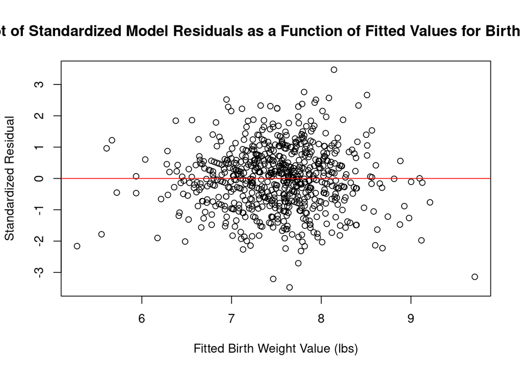

```r
fitted <- lm.bwfull_age$fitted.values # extract fitted values
resm <- resid(lm.bwfull_age)          # extract model residuals
standm <- rstandard(lm.bwfull_age)    # extract standardized residuals
studm <- rstudent(lm.bwfull_age)      # extract studentized residuals

#par(mfrow = c(3,1))                   # arranges plots
# residual plot:
#plot(fitted, resm, main = "Plot of Model Residuals as a Function of Fitted Values for Birth Weight", xlab = "Fitted Birth Weight Value (lbs)", ylab = "Residual (lbs)")
#abline(0,0, col = "red")
# standardized residual plot:
plot(fitted, standm, main = "Plot of Standardized Model Residuals as a Function of Fitted Values for Birth Weight", xlab = "Fitted Birth Weight Value (lbs)", ylab = "Standardized Residual")
abline(0,0, col = "red")
```

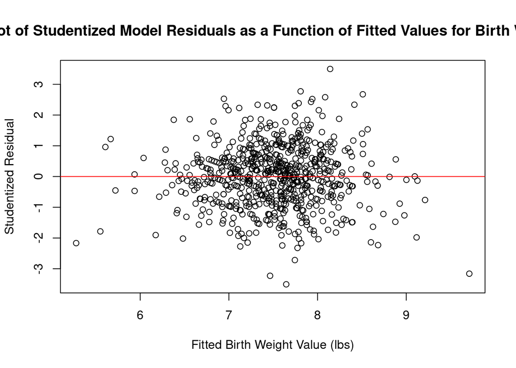

```r
# studentized residual plot:
plot(fitted, studm, main = "Plot of Studentized Model Residuals as a Function of Fitted Values for Birth Weight", xlab = "Fitted Birth Weight Value (lbs)", ylab = "Studentized Residual")
abline(0,0, col = "red")
```

The reference cell coding approach for creating dummy variables for smoking category ensures that the linearity assumption is met. The above plots do not show any overt change in variance with increasing $\hat{Y}$; suggest that the homoscedasticity assumption is likely met. Furthermore the residuals do not seem to be asymmetrically distributed, skewed, or multi-modal in any way; suggesting that the normality assumption is likely met.

## 7.2 Normality Analysis

Due to the large sample size the Shapiro-Wilk test will not provide helpful insights and thus will not be performed. The following R code creates a QQ Plot:

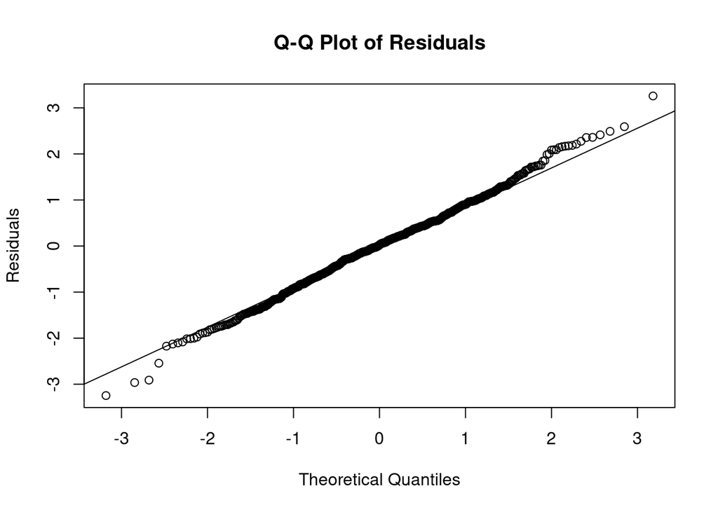

```r
qqnorm(resm, ylab = "Residuals", main = "Q-Q Plot of Residuals")
qqline(resm)
```

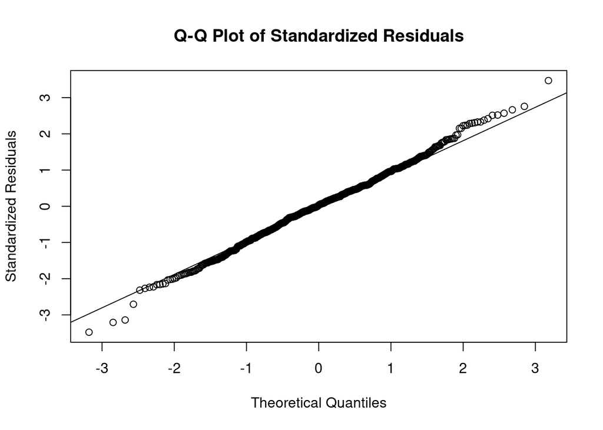

```r
qqnorm(standm, ylab = "Standardized Residuals", main = "Q-Q Plot of Standardized Residuals")
qqline(standm)
```

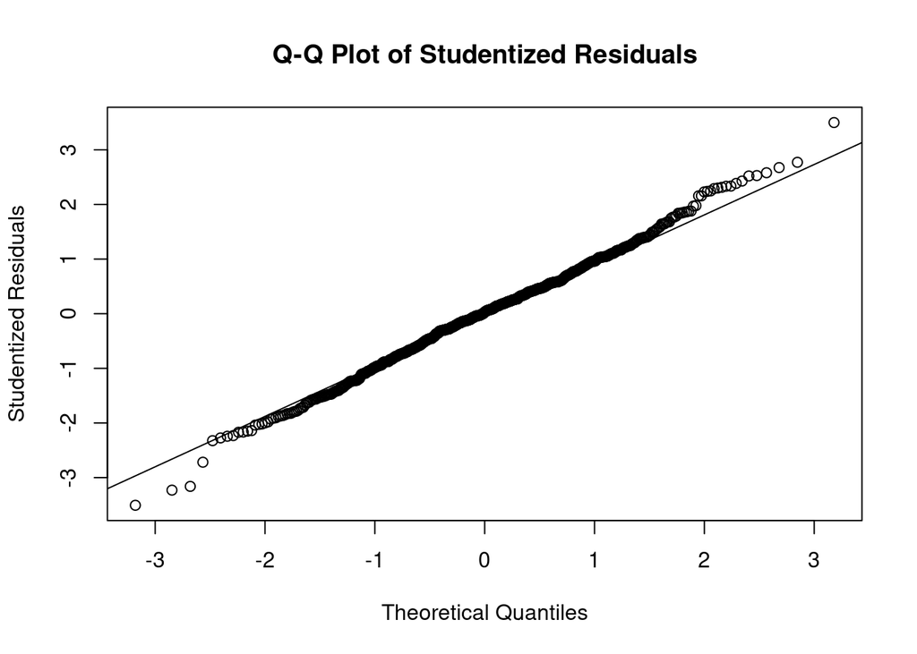

```r
qqnorm(studm, ylab = "Studentized Residuals", main = "Q-Q Plot of Studentized Residuals")
qqline(studm)
```

Q-Q plots suggest that the normality assumption is met. The handfull of points at the very edges of the plot may or may not be outliers, which brings us to our next section:

## 7.3 Influential Outlier Detection

The following code adds leverages & Cook’s distance to the dataset:

```r
k <- 7                                  # number of predictors in our model
h_limit <- 2*(1+k)/nrow(CHDS)           # recommended leverage threashold
CHDS$h <- hatvalues(lm.bwfull_age)      # Add leverages to the dataset
CHDS$c <- cooks.distance(lm.bwfull_age) # add Cook's distance to the dataset
```

The following code checks if any data points have Cook’s distance, $c$, greater than 1 or if the leverage, $h$, is greater than the recommended threshold of $2(k+1)/n$.

```r
CHDS[CHDS$c>1,]
```

```
##  [1] X       bwt     gestwks age     mnocig  mheight mppwt   BMI     BMI_cat
## [10] SMK_cat SMK1    SMK2    SMK3    h       c
## <0 rows> (or 0-length row.names)
```

```r
CHDS[CHDS$h>h_limit,]
```

```
##       X  bwt gestwks age mnocig mheight mppwt      BMI BMI_cat SMK_cat SMK1
## 9     9  3.3      29  32      0      64   142 24.37158       1       0    0
## 60   60  6.8      48  25      0      66   134 21.62580       1       0    0
## 84   84  6.5      34  38     35      61   108 20.40419       1       3    0
## 99   99  8.5      39  23     17      70   140 20.08571       1       2    0
## 166 166  5.3      33  20      7      63   109 19.30637       1       1    1
## 167 167  8.6      37  25     35      66   246 39.70110       4       3    0
## 226 226  8.8      41  36     12      71   173 24.12597       1       2    0
## 273 273  6.1      44  34     12      59   100 20.19535       1       2    0
## 291 291  5.5      36  21     12      60   115 22.45694       1       2    0
## 335 335  6.7      38  22     12      58   112 23.40547       1       2    0
## 356 356  8.1      44  30      2      58   150 31.34661       3       1    1
## 400 400 10.0      38  32      0      67   215 33.67008       3       0    0
## 404 404  7.6      39  26      0      66   210 33.89118       3       0    0
## 445 445  7.3      46  22      2      62   164 29.99272       2       1    1
```

[output cut: 27 more lines]

Upon examination of the data reported in the second table, none of the data is wildly implausible, with the exception of a 48 week gestational age. A 48-week gestational age is well above the 0.1th percentile of gestational age based on ultrasound based estimates of gestation; and furthermore none of the women in this study (n=1867) had gestation age greater than 46 weeks.<sup>1</sup>

We can create a new dataset with this observation (observation 60) removed:

```r
CHDS_60 <- CHDS[-c(60),]
```

And a new parsimonious model can be created:

```r
lm.par_60 <- lm(bwt ~ SMK1 + SMK2 + SMK3 + gestwks + mheight + BMI, data = CHDS_60)
summary(lm.par_60)
```

```
##
## Call:
## lm(formula = bwt ~ SMK1 + SMK2 + SMK3 + gestwks + mheight + BMI,
##     data = CHDS_60)
##
## Residuals:
##     Min      1Q  Median      3Q     Max
## -3.2487 -0.6078  0.0073  0.5562  3.2309
##
## Coefficients:
##             Estimate Std. Error t value Pr(>|t|)
## (Intercept) -8.16421    1.25041  -6.529 1.30e-10 ***
## SMK1        -0.18009    0.10571  -1.704  0.08890 .
## SMK2        -0.55037    0.12595  -4.370 1.44e-05 ***
## SMK3        -0.41179    0.09542  -4.315 1.83e-05 ***
## gestwks      0.24136    0.01954  12.355  < 2e-16 ***
## mheight      0.08226    0.01459   5.638 2.54e-08 ***
## BMI          0.04403    0.01391   3.166  0.00162 **
## ---
## Signif. codes:  0 '***' 0.001 '**' 0.01 '*' 0.05 '.' 0.1 ' ' 1
##
## Residual standard error: 0.9353 on 672 degrees of freedom
## Multiple R-squared:  0.274,  Adjusted R-squared:  0.2675
## F-statistic: 42.26 on 6 and 672 DF,  p-value: < 2.2e-16
```

Upon comparison to the original parsimonious model we can see that most $\hat{\beta}_i$ have very similar values, with a slight change in $\hat{\beta}_0$.

## 7.4 Collinearity Assessment

The variance inflation factor approach will be used to assess collinearity. The following R code calculates the factor for each $\hat{\beta}_i$:

```r
vif(lm.par_60)
```

```
##     SMK1     SMK2     SMK3  gestwks  mheight      BMI
## 1.116076 1.080543 1.094130 1.012350 1.018422 1.036611
```

```r
mean(vif(lm.par_60))
```

```
## [1] 1.059689
```

All factors are well below 10; indicating that collinearity is likely minimal.

# 8 Mediation analysis

## 8.1 BMI

## 8.2 Maternal Weight

## 8.3 Gestational Age

# 9 References

1. Hoffman CS, Messer LC, Mendola P, Savitz DA, Herring AH, Hartmann KE. Comparison of gestational age at birth based on last menstrual period and ultrasound during the first trimester. Paediatr Perinat Epidemiol. 2008 Nov;22(6):587-96. doi: 10.1111/j.1365-3016.2008.00965.x. PMID: 19000297.